# Zaman Serileri Analizine Giriş

## 2.2 Bileşenler

Zaman serileri; deterministik ve stokastik öğelerden oluşmaktadır. **Deterministik öğeler**, matematiksel olarak formüle edilebilen öğelerdir. **Stokastik öğeler** ise rassal süreçlerden doğmaktadır. Zaman serileri bu iki öğelerin etkisini taşıyan 4 bileşenden oluşmaktadır.

Bunlar;

| **Bileşenler** | **Gösterim** |
| --- | --- |
| Trend *(Trend)* | T |
| Sezonsal *(Seasonal)* | S |
| Konjoktür *(Conjuncture)* | C |
| Düzensiz *(Irregular)* | I |

Ve bu bileşenler de **Toplamsal Model** ve **Çarpımsal Model** olarak ikiye ayrılmaktadır. Çarpımsal model, logaritmik dönüşüm ile toplamsal modele indirgenebilir.

$$Y_t = T_t + S_t + C_t + I_t$$
$$Y_t = T_t S_t C_t I_t$$
Zaman bileşenleri ayrıştırması sonucu **rassal(random)** olarak adlandırılan bir seri elde edilir. Bu yeni seride trend, sezonsallık ve konjoktür etkilerinin etkisi yer almamaktadır.

```r
nottem #1920 - 1939 Yılları Arasında Nottingham'da ki Aylık Ortalama Sıcaklık
```

```
##       Jan  Feb  Mar  Apr  May  Jun  Jul  Aug  Sep  Oct  Nov  Dec
## 1920 40.6 40.8 44.4 46.7 54.1 58.5 57.7 56.4 54.3 50.5 42.9 39.8
## 1921 44.2 39.8 45.1 47.0 54.1 58.7 66.3 59.9 57.0 54.2 39.7 42.8
## 1922 37.5 38.7 39.5 42.1 55.7 57.8 56.8 54.3 54.3 47.1 41.8 41.7
## 1923 41.8 40.1 42.9 45.8 49.2 52.7 64.2 59.6 54.4 49.2 36.3 37.6
## 1924 39.3 37.5 38.3 45.5 53.2 57.7 60.8 58.2 56.4 49.8 44.4 43.6
## 1925 40.0 40.5 40.8 45.1 53.8 59.4 63.5 61.0 53.0 50.0 38.1 36.3
## 1926 39.2 43.4 43.4 48.9 50.6 56.8 62.5 62.0 57.5 46.7 41.6 39.8
## 1927 39.4 38.5 45.3 47.1 51.7 55.0 60.4 60.5 54.7 50.3 42.3 35.2
## 1928 40.8 41.1 42.8 47.3 50.9 56.4 62.2 60.5 55.4 50.2 43.0 37.3
## 1929 34.8 31.3 41.0 43.9 53.1 56.9 62.5 60.3 59.8 49.2 42.9 41.9
## 1930 41.6 37.1 41.2 46.9 51.2 60.4 60.1 61.6 57.0 50.9 43.0 38.8
## 1931 37.1 38.4 38.4 46.5 53.5 58.4 60.6 58.2 53.8 46.6 45.5 40.6
## 1932 42.4 38.4 40.3 44.6 50.9 57.0 62.1 63.5 56.3 47.3 43.6 41.8
## 1933 36.2 39.3 44.5 48.7 54.2 60.8 65.5 64.9 60.1 50.2 42.1 35.8
## 1934 39.4 38.2 40.4 46.9 53.4 59.6 66.5 60.4 59.2 51.2 42.8 45.8
## 1935 40.0 42.6 43.5 47.1 50.0 60.5 64.6 64.0 56.8 48.6 44.2 36.4
## 1936 37.3 35.0 44.0 43.9 52.7 58.6 60.0 61.1 58.1 49.6 41.6 41.3
## 1937 40.8 41.0 38.4 47.4 54.1 58.6 61.4 61.8 56.3 50.9 41.4 37.1
## 1938 42.1 41.2 47.3 46.6 52.4 59.0 59.6 60.4 57.0 50.7 47.8 39.2
## 1939 39.4 40.9 42.4 47.8 52.4 58.0 60.7 61.8 58.2 46.7 46.6 37.8
```

```r
class(nottem)
```

```
## [1] "ts"
```

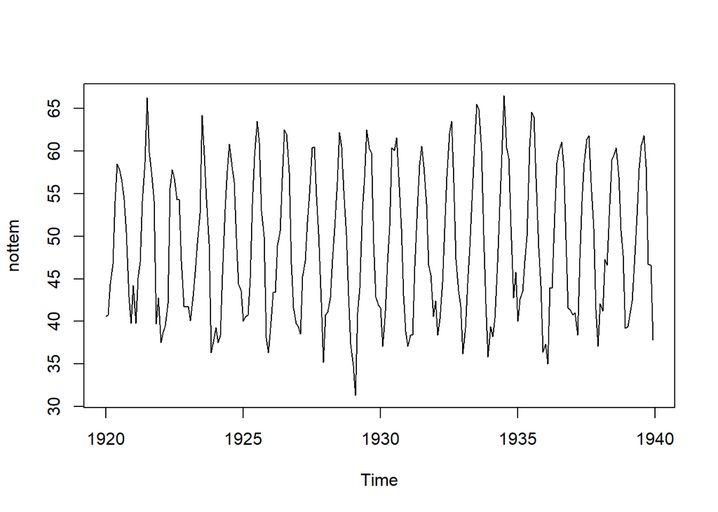

```r
plot(nottem)
```

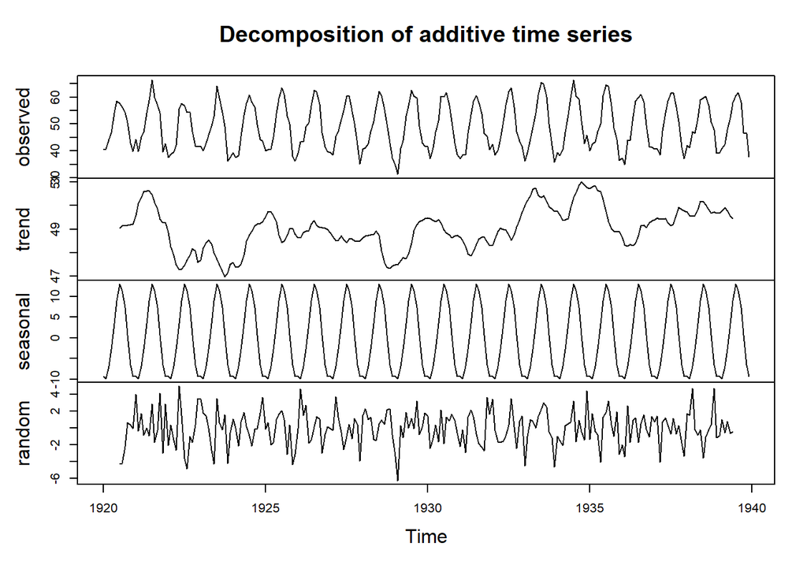

```r
plot(decompose(nottem))
```

Grafikte gösterilen zaman bileşenlerin katsayılarına aşağıdaki komut ile ilgili bileşeni seçerek ulaşılabilir.

```r
decompose(nottem)
```

```
## $x
##       Jan  Feb  Mar  Apr  May  Jun  Jul  Aug  Sep  Oct  Nov  Dec
## 1920 40.6 40.8 44.4 46.7 54.1 58.5 57.7 56.4 54.3 50.5 42.9 39.8
## 1921 44.2 39.8 45.1 47.0 54.1 58.7 66.3 59.9 57.0 54.2 39.7 42.8
## 1922 37.5 38.7 39.5 42.1 55.7 57.8 56.8 54.3 54.3 47.1 41.8 41.7
## 1923 41.8 40.1 42.9 45.8 49.2 52.7 64.2 59.6 54.4 49.2 36.3 37.6
## 1924 39.3 37.5 38.3 45.5 53.2 57.7 60.8 58.2 56.4 49.8 44.4 43.6
## 1925 40.0 40.5 40.8 45.1 53.8 59.4 63.5 61.0 53.0 50.0 38.1 36.3
## 1926 39.2 43.4 43.4 48.9 50.6 56.8 62.5 62.0 57.5 46.7 41.6 39.8
## 1927 39.4 38.5 45.3 47.1 51.7 55.0 60.4 60.5 54.7 50.3 42.3 35.2
## 1928 40.8 41.1 42.8 47.3 50.9 56.4 62.2 60.5 55.4 50.2 43.0 37.3
## 1929 34.8 31.3 41.0 43.9 53.1 56.9 62.5 60.3 59.8 49.2 42.9 41.9
## 1930 41.6 37.1 41.2 46.9 51.2 60.4 60.1 61.6 57.0 50.9 43.0 38.8
## 1931 37.1 38.4 38.4 46.5 53.5 58.4 60.6 58.2 53.8 46.6 45.5 40.6
## 1932 42.4 38.4 40.3 44.6 50.9 57.0 62.1 63.5 56.3 47.3 43.6 41.8
```

[output cut: 170 more lines]

```r
decompose(nottem)$seasonal
```

```
##             Jan        Feb        Mar        Apr        May        Jun
## 1920 -9.3393640 -9.8998904 -6.9466009 -2.7573465  3.4533991  8.9865132
## 1921 -9.3393640 -9.8998904 -6.9466009 -2.7573465  3.4533991  8.9865132
## 1922 -9.3393640 -9.8998904 -6.9466009 -2.7573465  3.4533991  8.9865132
## 1923 -9.3393640 -9.8998904 -6.9466009 -2.7573465  3.4533991  8.9865132
## 1924 -9.3393640 -9.8998904 -6.9466009 -2.7573465  3.4533991  8.9865132
## 1925 -9.3393640 -9.8998904 -6.9466009 -2.7573465  3.4533991  8.9865132
## 1926 -9.3393640 -9.8998904 -6.9466009 -2.7573465  3.4533991  8.9865132
## 1927 -9.3393640 -9.8998904 -6.9466009 -2.7573465  3.4533991  8.9865132
## 1928 -9.3393640 -9.8998904 -6.9466009 -2.7573465  3.4533991  8.9865132
## 1929 -9.3393640 -9.8998904 -6.9466009 -2.7573465  3.4533991  8.9865132
## 1930 -9.3393640 -9.8998904 -6.9466009 -2.7573465  3.4533991  8.9865132
## 1931 -9.3393640 -9.8998904 -6.9466009 -2.7573465  3.4533991  8.9865132
## 1932 -9.3393640 -9.8998904 -6.9466009 -2.7573465  3.4533991  8.9865132
## 1933 -9.3393640 -9.8998904 -6.9466009 -2.7573465  3.4533991  8.9865132
```

[output cut: 27 more lines]

```r
decompose(nottem)$trend
```

```
##           Jan      Feb      Mar      Apr      May      Jun      Jul      Aug
## 1920       NA       NA       NA       NA       NA       NA 49.04167 49.15000
## 1921 49.56667 50.07083 50.32917 50.59583 50.61667 50.60833 50.45417 50.12917
## 1922 48.87083 48.24167 47.89583 47.48750 47.27917 47.32083 47.45417 47.69167
## 1923 47.68333 48.21250 48.43750 48.52917 48.38750 47.98750 47.71250 47.50000
## 1924 47.59167 47.39167 47.41667 47.52500 47.88750 48.47500 48.75417 48.90833
## 1925 49.51250 49.74167 49.71667 49.58333 49.32917 48.76250 48.42500 48.51250
## 1926 48.64167 48.64167 48.87083 48.92083 48.92917 49.22083 49.37500 49.17917
## 1927 48.83750 48.68750 48.50833 48.54167 48.72083 48.55833 48.42500 48.59167
## 1928 48.63333 48.70833 48.73750 48.76250 48.78750 48.90417 48.74167 48.08333
## 1929 47.47917 47.48333 47.65833 47.80000 47.75417 47.94167 48.41667 48.94167
## 1930 49.48333 49.43750 49.37500 49.32917 49.40417 49.27917 48.96250 48.82917
## 1931 48.66250 48.54167 48.26667 47.95417 47.87917 48.05833 48.35417 48.57500
## 1932 48.30417 48.58750 48.91250 49.04583 48.99583 48.96667 48.75833 48.53750
## 1933 50.00000 50.20000 50.41667 50.69583 50.75417 50.44167 50.32500 50.41250
```

[output cut: 27 more lines]

```r
decompose(nottem)$random
```

```
##               Jan          Feb          Mar          Apr          May
## 1920           NA           NA           NA           NA           NA
## 1921  3.972697368 -0.370942982  1.717434211 -0.838486842  0.029934211
## 1922 -2.031469298  0.358223684 -1.449232456 -2.630153509  4.967434211
## 1923  3.456030702  1.787390351  1.409100877  0.028179825 -2.640899123
## 1924  1.047697368  0.008223684 -2.170065789  0.732346491  1.859100877
## 1925 -0.173135965  0.658223684 -1.970065789 -1.725986842  1.017434211
## 1926 -0.102302632  4.658223684  1.475767544  2.736513158 -1.782565789
## 1927 -0.098135965 -0.287609649  3.738267544  1.315679825 -0.474232456
## 1928  1.506030702  2.291557018  1.009100877  1.294846491 -1.340899123
## 1929 -3.339802632 -6.283442982  0.288267544 -1.142653509  1.892434211
## 1930  1.456030702 -2.437609649 -1.228399123  0.328179825 -1.657565789
## 1931 -2.223135965 -0.241776316 -2.920065789  1.303179825  2.167434211
## 1932  3.435197368 -0.287609649 -1.665899123 -1.688486842 -1.549232456
## 1933 -4.460635965 -1.000109649  1.029934211  0.761513158 -0.007565789
```

[output cut: 48 more lines]

```r
decompose(nottem)$type
```

```
## [1] "additive"
```

Zaman serisi bileşenleri, **decompose()** komutunda varsayılan olarak **toplamsal (additive) model** yöntemini kullanmaktadır. Eğer **çarpımsal (multiplicative) model** ile çalışılacak ise, ayrıca parametresinin aşağıdaki şekilde belirtilmesi gerekmektedir.

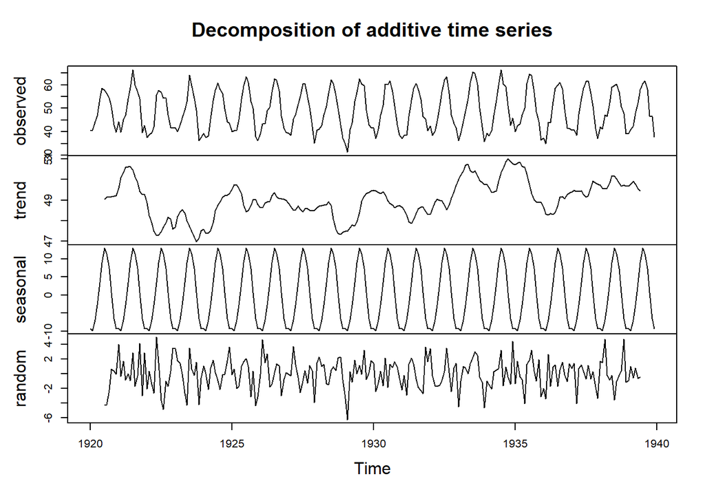

```r
plot(decompose(nottem, "additive"))
```

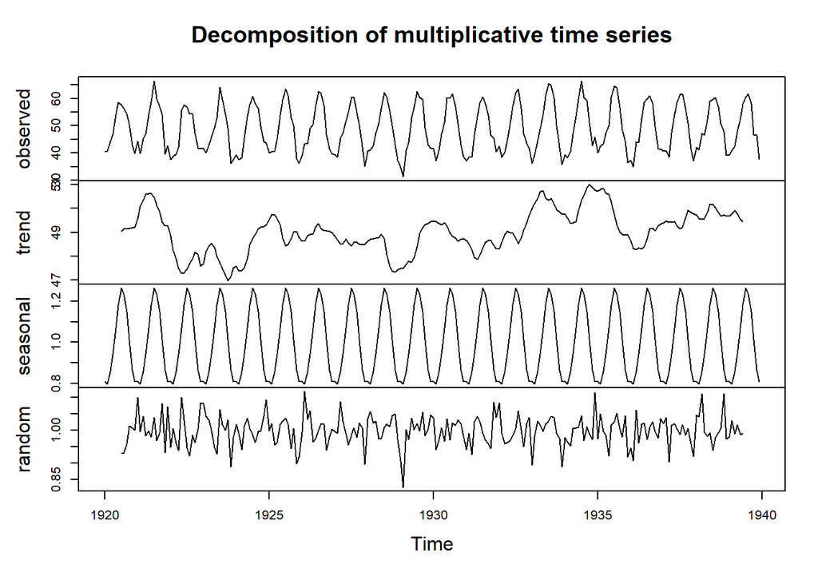

```r
plot(decompose(nottem, "multiplicative"))
```